# Trabajo Final de Máster (2da parte)

### Risk Score Lag

El análisis de binning evidencia una clara capacidad discriminante de la variable, con un Information Value global de 1.244. El primer corte ($- \infty, 0.32$) agrupa el 46.1% de los registros con una baja tasa de eventos (3.99%), mientras que el segundo $[0.32, 0.40)$ concentra el 46.5% con una tasa moderada (22.96%). Finalmente, el tercer intervalo $[0.40, \infty)$ representa solo el 7.4% de los registros, pero con una tasa de eventos muy elevada (62.16%), confirmando el alto poder predictivo de la variable.

```python
variable = 'risk_score_lag'

optb, binning_table = optimal_binning(X_train, y_train, variable)
binning_table.build()
```

|  | Bin | Count | Count (%) | Non-event | Event | Event rate | WoE | IV | JS |
| --- | --- | --- | --- | --- | --- | --- | --- | --- | --- |
| 0 | (-inf, 0.32) | 73574 | 0.460788 | 70641 | 2933 | 0.039865 | 1.605431 | 0.685020 | 0.077474 |
| 1 | [0.32, 0.40) | 74208 | 0.464759 | 57173 | 17035 | 0.229557 | -0.365342 | 0.069620 | 0.008654 |
| 2 | [0.40, inf) | 11888 | 0.074454 | 4498 | 7390 | 0.621635 | -2.072649 | 0.489408 | 0.052144 |
| 3 | Special | 0 | 0.000000 | 0 | 0 | 0.000000 | 0.0 | 0.000000 | 0.000000 |
| 4 | Missing | 0 | 0.000000 | 0 | 0 | 0.000000 | 0.0 | 0.000000 | 0.000000 |
| Totals |  | 159670 | 1.000000 | 132312 | 27358 | 0.171341 |  | 1.244048 | 0.138273 |

```python
# Transformación WOE en el conjunto train
new_variable_name = f"{variable}_WOE"
X_train[new_variable_name] = optb.transform(X_train[variable].values, metric="woe")

# Transformación WOE en el conjunto test
new_variable_name = f"{variable}_WOE"
X_test[new_variable_name] = optb.transform(X_test[variable].values, metric="woe")
```

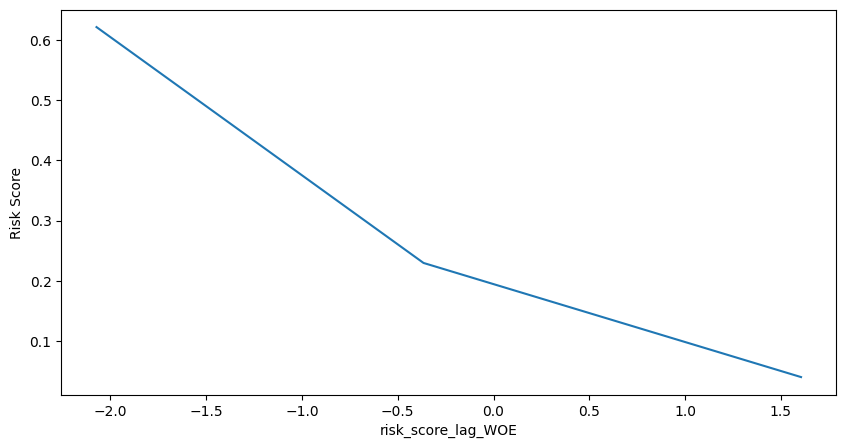

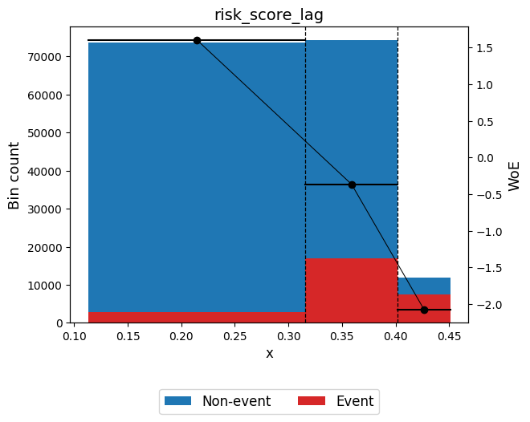

```python
# Crear el primer gráfico por separado
plt.figure(figsize=(10, 5))
plt.plot(pd.crosstab(X_train[new_variable_name].values, y_train, normalize=0).iloc[:,1])
plt.xlabel(new_variable_name)
plt.ylabel("Risk Score")
plt.show()

# Crear el segundo gráfico por separado
plt.figure(figsize=(10, 5))
binning_table.plot(metric="woe", add_special = False, add_missing = False, style = "actual")
```

# Modelos de Clasificación

El siguiente y último paso de este proceso es continuar con la programación de un modelo de clasificación binario. Después de varias iteraciones se llegó a la conclusión que el mejor set de variables que maximizan el desempeño del modelo viene dado por:

- Coordenadas (Latitud y Longitud)
- El score de riesgo con lag (en las vecindades de donde ocurrió el incidente) en su transformación WoE
- El ingreso medio en la zona donde ocurrió el crimen en su respectiva transformación WoE
- La magnitud de la dependencia espacial (HH, LL, HL, LH) en donde ocurrió el crimen, también en su recategorización mediante el análisis por WoE

```python
# Definimos la variable objetivo
target = "risk_level"

# Definimos las features
features = [
    "lon", "lat",
    # 'time_of_day_WOE',
    # "GiniIndex_WOE",
    # 'hour_sin','hour_cos',
    # 'dc_dist',
    'risk_score_lag_WOE',
    'mean_income_WOE',
    # 'non_white_population_WOE',
    # 'white_population_WOE',
    # 'household_25k_or_less_WOE',
    # 'household_150k_or_more_WOE',
    # "sig",
    "labels_WOE"
]

X_train_model = X_train[features].copy()

# Aseguramos que el tipo de dato se cumpla
num_features = X_train_model.select_dtypes(include=["int64", "float64", "int32"]).columns.tolist()
cat_features = X_train_model.select_dtypes(include=["object", "bool"]).columns.tolist()

# Identificar variables WOE
woe_features = [col for col in X_train_model.columns if "_WOE" in col]
# Detectar variables binarias tipo bandera (como sig) → tratarlas como categóricas
binary_features = [col for col in num_features if X_train_model[col].nunique() == 2 and col not in woe_features]
# Aseguramos que no se procesen como numéricas estándar
num_features = [col for col in num_features if col not in woe_features + binary_features]
cat_features = cat_features + binary_features

print("Numéricas (escaladas):", num_features)
print("Categóricas (one-hot):", cat_features)
print("WOE (sin transformar):", woe_features)
```

```
Numéricas (escaladas): ['lon', 'lat']
Categóricas (one-hot): []
WOE (sin transformar): ['risk_score_lag_WOE', 'mean_income_WOE', 'labels_WOE']
```

Se define un proceso de preprocesamiento de datos en donde para aquellas variables categóricas se realiza un one hot encoder, para las variables numéricas se hace una estandarización y para las variables transformadas por WoE el preprocesamiento no aplica.

```python
preprocessor = ColumnTransformer(
    transformers=[
        ("num", StandardScaler(), num_features),   # Estandarizar numéricas
        ("cat", OneHotEncoder(handle_unknown="ignore"), cat_features),  # One-hot en categóricas
        ("woe", "passthrough", woe_features)
    ]
)
```

### Random Forest

Se procede a programar un modelo random forest con un set básico de hiperparámetros para comparar performance más adelante.

```python
rf_model = RandomForestClassifier(
    n_estimators=200,
    max_depth=None,
    min_samples_leaf = 1,
    max_features = 'sqrt',
    random_state=42,
    n_jobs=-1
)
```

El siguiente pipeline toma los datos crudos y primero aplica un preprocesamiento que codifica las variables categóricas y escala las numéricas, dejándolos listos para el modelo.

Luego, utiliza SMOTE para generar ejemplos sintéticos de la clase minoritaria, equilibrando parcialmente el dataset según la proporción indicada. Esto porque ya se vio que tanto en el train como en el split hay desbalanceo de aproximadamente 85/15, por lo cual es valiosos la generación de estos datos sintéticos con el fin de que el modelo tenga una mejor capacidad de generalizar.

Finalmente, entrena el modelo de Random Forest sobre estos datos ya transformados y balanceados, de manera que todo el flujo —preprocesamiento, balanceo y modelado— se aplique de forma consistente y reproducible.

```python
# Construir pipeline con SMOTE + preprocesador + modelo
clf = ImbPipeline(steps=[
    ("preprocessor", preprocessor),   # encoding y escalado
    ("smote", SMOTE(sampling_strategy=0.5, random_state=42)),
    ("model", rf_model)
])
```

Se procede a verificar los resultados con validación cruzada con 5 folds:

```python
# Validación cruzada
cv = StratifiedKFold(n_splits=5, shuffle=True, random_state=42)

# Definir métricas importantes que se evaluarán con la CV
scoring = {
    'accuracy': 'accuracy',
    'precision_macro': 'precision_macro',
    'recall_macro': 'recall_macro',
    'f1_macro': 'f1_macro',
    'recall_class_1': make_scorer(recall_score, pos_label=1),  # Crítico: no perder lugares peligrosos
    'precision_class_1': make_scorer(precision_score, pos_label=1),  # Reducir falsas alarmas
    'recall_class_0': make_scorer(recall_score, pos_label=0),  # Detectar lugares seguros
    'precision_class_0': make_scorer(precision_score, pos_label=0)   # Confianza en "seguro"
}

start_time = time.time()
cv_results = cross_validate(
    clf, X_train_model, y_train,
    cv=cv,
    scoring=scoring,
    return_train_score=True,
    n_jobs=-1,
    verbose=1
)

elapsed_time = time.time() - start_time
print(f"El proceso de validación cruzada terminó correctamente y duró {elapsed_time:.2f} segundos.")
```

```
[Parallel(n_jobs=-1)]: Using backend LokyBackend with 8 concurrent workers.
[Parallel(n_jobs=-1)]: Done   2 out of   5 | elapsed:   33.3s remaining:   50.0s
```

```
El proceso de validación cruzada terminó correctamente y duró 74.09 segundos.
```

```
[Parallel(n_jobs=-1)]: Done   5 out of   5 | elapsed:  1.2min finished
```

```python
# === ANÁLISIS DE RESULTADOS ===
print("="*20)
print("Resultados")
print("="*20)

for metric_name in scoring.keys():
    test_scores = cv_results[f'test_{metric_name}']
    train_scores = cv_results[f'train_{metric_name}']

    print(f"\n{metric_name.upper().replace('_', ' ')}:")
    print(f"  Test:  {test_scores.mean():.4f} (±{test_scores.std():.4f})")
    print(f"  Train: {train_scores.mean():.4f} (±{train_scores.std():.4f})")
```

```
====================
Resultados
====================

ACCURACY:
  Test:  0.8910 (±0.0009)
  Train: 0.9610 (±0.0003)

PRECISION MACRO:
  Test:  0.8022 (±0.0014)
  Train: 0.9169 (±0.0005)

RECALL MACRO:
  Test:  0.8484 (±0.0017)
  Train: 0.9546 (±0.0009)

F1 MACRO:
  Test:  0.8220 (±0.0013)
  Train: 0.9343 (±0.0005)

RECALL CLASS 1:
  Test:  0.7835 (±0.0037)
  Train: 0.9449 (±0.0020)

PRECISION CLASS 1:
  Test:  0.6512 (±0.0027)
  Train: 0.8455 (±0.0011)

RECALL CLASS 0:
  Test:  0.9132 (±0.0011)
  Train: 0.9643 (±0.0003)

PRECISION CLASS 0:
  Test:  0.9533 (±0.0007)
  Train: 0.9883 (±0.0004)
```

- Identifica correctamente 91.3% de lugares seguros
- Detecta 78.4% de lugares peligrosos
- 65.1% de alertas son reales

Habiendo validado los resultados con CV, el siguiente paso es entrenar el modelo con todos los datos disponibles:

```python
# === Entrenamiento final ===
print("\n" + "="*20)
print("Modelo Final")
print("="*20)

print("Entrenando pipeline completo en todos los datos de train...")
clf.fit(X_train_model, y_train)

# Predicciones en test set
y_pred = clf.predict(X_test)
y_prob = clf.predict_proba(X_test)[:, 1]

# Reporte final
print("\n Reporte final en test:")
print(classification_report(y_test, y_pred,
                          target_names=['Seguro (0)', 'Peligroso (1)']))
```

```
====================
Modelo Final
====================
Entrenando pipeline completo en todos los datos de train...

 Reporte final en test:
               precision    recall  f1-score   support

   Seguro (0)       0.95      0.90      0.92     49088
Peligroso (1)       0.59      0.78      0.67      9517

     accuracy                           0.88     58605
    macro avg       0.77      0.84      0.80     58605
 weighted avg       0.90      0.88      0.88     58605
```

El modelo muestra un rendimiento sólido en el test set, con una precisión general del 88%, aunque al ser un problema de clasificación altamente desbalanceado no basta con este accuracy general.

El aspecto más relevante debería ser su capacidad para identificar lugares peligrosos, donde se observa un recall de 78% para la clase "Peligroso", lo que implica que captura aproximadamente 8 de cada 10 zonas de alto riesgo. La precisión para esta clase es de 59%, aceptable dada la desproporción de clases (9,517 peligrosos vs 49,088 seguros). Este nivel de precisión indica que aproximadamente 6 de cada 10 predicciones de "lugar peligroso" son correctas, lo cual es razonable para un sistema de alerta temprana donde se puede tolerar cierto nivel de falsos positivos a cambio de una mayor capacidad de detección.

La curva ROC es la siguiente, aunque vale la pena destacar que no es una buena métrica de desempeño dado el desbalanceo presente en los datos:

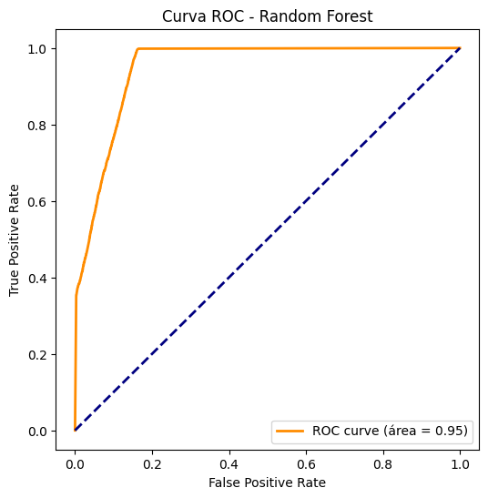

```python
# Curva ROC
fpr, tpr, thresholds = roc_curve(y_test, y_prob)
roc_auc = auc(fpr, tpr)

plt.figure(figsize=(6,6))
plt.plot(fpr, tpr, color="darkorange", lw=2, label=f"ROC curve (área = {roc_auc:.2f})")
plt.plot([0,1], [0,1], color="navy", lw=2, linestyle="--")
plt.xlabel("False Positive Rate")
plt.ylabel("True Positive Rate")
plt.title("Curva ROC - Random Forest")
plt.legend(loc="lower right")
plt.show()
```

El modelo demuestra una sólida capacidad predictiva, sustentada principalmente en variables geoespaciales clave. La latitud y longitud se destacan como las más importantes, seguidas de la correlación local de la zona postal asociada a las coordenadas, lo que confirma que la ubicación geográfica es el factor determinante para identificar lugares peligrosos. Esta jerarquía de importancia resulta coherente desde una perspectiva criminológica, dado que los delitos tienden a concentrarse espacialmente en áreas específicas. Además, el modelo no se limita a coordenadas geográficas, sino que integra de manera efectiva variables socioeconómicas, como el ingreso medio, lo que permite capturar patrones tanto espaciales como contextos socioeconómicos. Esta combinación proporciona un enfoque integral y robusto para la predicción de riesgo, reflejando una comprensión más completa del fenómeno delictivo y ofreciendo información valiosa para la toma de decisiones estratégicas en seguridad pública.

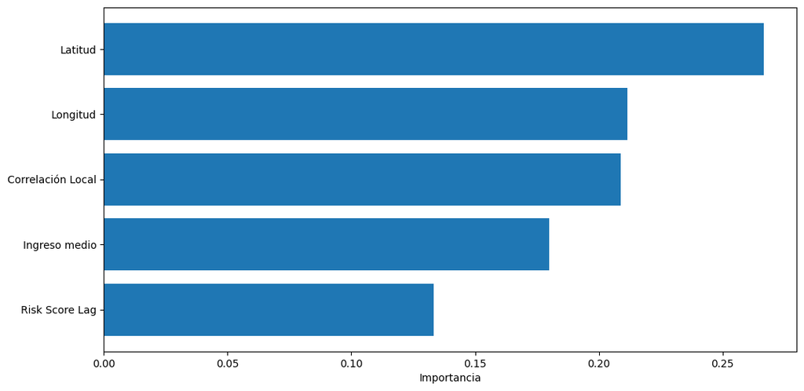

```python
rf_model = clf.named_steps["model"]

feature_names = clf.named_steps["preprocessor"].get_feature_names_out()

importances = rf_model.feature_importances_

feat_imp = pd.DataFrame({
    "feature": feature_names,
    "importance": importances
}).sort_values(by="importance", ascending=False)

feature_rename = {
    "num__lat": "Latitud",
    "num__lon": "Longitud",
    "woe__labels_WOE": "Correlación Local",
    "woe__mean_income_WOE": "Ingreso medio",
    "woe__risk_score_lag_WOE": "Risk Score Lag"

}
feat_imp["feature_renamed"] = feat_imp["feature"].map(feature_rename).fillna(feat_imp["feature"])
plt.figure(figsize=(12, 6))
plt.barh(feat_imp["feature_renamed"][:20], feat_imp["importance"][:20])
plt.gca().invert_yaxis()
plt.xlabel("Importancia")
plt.show()
```

#### Grid Search

```python
# Definir un grid pequeño y enfocado
start_time = time.time()
param_grid = {
    "model__max_depth": [10, 15, None],         # limitar o no la profundidad
    "model__min_samples_leaf": [1, 5, 10],      # suavizar hojas
    "model__max_features": ["sqrt", "log2"],    # aleatoriedad en splits
    "model__n_estimators": [100, 200]           # mantener bajo para eficiencia
}

# Definir scorer para recall de la clase positiva (1)
recall_minority = make_scorer(recall_score, pos_label=1)

# GridSearch con validación cruzada estratificada
grid_search = GridSearchCV(
    clf,
    param_grid=param_grid,
    cv=3,                         # 3 folds para no sobrecargar tanto
    scoring=recall_minority,
    n_jobs=-1,
    verbose=2
)

grid_search.fit(X_train_model, y_train)

print("Mejores parámetros:", grid_search.best_params_)
print("Mejor score:", grid_search.best_score_)

# Reentrenar modelo final con los mejores parámetros encontrados
best_model = grid_search.best_estimator_

print("Entrenando modelo final con los mejores parámetros en todo el train...")
best_model.fit(X_train_model, y_train)

# Evaluación en test
y_pred = best_model.predict(X_test)
print("Reporte final en test:")
print(classification_report(y_test, y_pred,
                            target_names=['Seguro (0)', 'Peligroso (1)']))

elapsed_time = time.time() - start_time
print(f"El proceso de validación Grid Search terminó correctamente y duró {elapsed_time:.2f} segundos.")
```

```
Fitting 3 folds for each of 36 candidates, totalling 108 fits
Mejores parámetros: {'model__max_depth': 10, 'model__max_features': 'sqrt', 'model__min_samples_leaf': 10, 'model__n_estimators': 200}
Mejor score: 0.9986475485923934
Entrenando modelo final con los mejores parámetros en todo el train...
Reporte final en test:
               precision    recall  f1-score   support

   Seguro (0)       1.00      0.84      0.91     49088
Peligroso (1)       0.54      1.00      0.70      9517

     accuracy                           0.86     58605
    macro avg       0.77      0.92      0.81     58605
 weighted avg       0.93      0.86      0.88     58605

El proceso de validación Grid Search terminó correctamente y duró 839.58 segundos.
```

Antes del Grid Search, el modelo tenía un equilibrio razonable entre precisión y recall: para la clase crítica (zonas peligrosas), el recall era 0.78 y la precisión 0.59. Esto significa que detectaba correctamente la mayoría de los lugares peligrosos, y al mismo tiempo no generaba demasiados falsos positivos. La exactitud general era 0.88 y el F1 macro 0.80, métricas sólidas considerando la naturaleza desbalanceada del problema.

En conclusión, el modelo sin tunear es preferible porque mantiene un equilibrio más realista entre detectar zonas peligrosas y no saturar de falsos positivos, lo cual es crítico para decisiones operativas en tu problema. En cambio, el modelo tuneado con Grid Search prioriza demasiado recall y pierde confiabilidad práctica.

```python
rf_model = RandomForestClassifier(
    n_estimators=200,
    max_depth=None,
    min_samples_leaf = 1,
    max_features = 'sqrt',
    random_state=42,
    n_jobs=-1
)
```

FIN DEL TRABAJO